# ✍ Relatório Final - ATP de Preparação e Análise Exploratória de Dados

# Curso de Tecnologia em Big Data e Inteligência Analítica

# Pontifícia Universidade Católica do Paraná (PUCPR)

🕵 `JUAN MANOEL MARINHO NASCIMENTO` - `JUANENGML@GMAIL.COM`

# Introdução

Nesta atividade, vamos trabalhar com um conjunto de dados da empresa Enron. A Enron foi uma das maiores empresas de energia dos Estados Unidos. No seu auge, chegou a valer 65 bilhões de dólares e ela faliu em 24 dias. A Enron foi fundada em 1985 por Kenneth Lay com a fusão da Houston Natural Gas e da InterNorth. Anos depois, quando Jeffrey Skilling tomou posse, ele estabeleceu um conjunto de diretores que criaram entidades fictícias, relatórios financeiros fracos e contabilidades erradas, que somadas, esconderam bilhões de dólares e projetos fracassados dos investidores. O esquema foi tão complexo que nem mesmo auditorias profissionais foram capazes de identificar estes problemas, e a empresa foi investigada pelo governo norte-americano, incluindo a sua suprema corte. A base de dados utilizada na investigação incluía aproximadamente 500 mil e-mails trocados por empregados da Enron. Estes e-mails foram obtidos pela comissão regulatória de energia dos Estados Unidos durante sua investigação. A base de dados que vamos utilizar sumariza informações não apenas destes e-mails, mas também de salário e ações da bolsa de valores dos envolvidos. Além disso, os funcionários são divididos em pessoas de interesse (Person of Interest, ou POI), que participaram da fraude; e funcionários que não participaram da fraude, ou não-POIs.

## Dicas

Nesta análise e preparação de dados, nós precisamos ir além de explorações simples. Garanta que toda exploração e análise de dados seja acompanhada de uma análise crítica.

# Importando as bibliotecas

Na célula abaixo, as principais bibliotecas para análise de dados são importadas. Sinta-se a vontade para importar mais bibliotecas de acordo com sua demanda e/ou preferência, contudo, garanta que todos os comandos de `import` sejam feitos na célula abaixo.

```python
import numpy as np
import pandas as pd
import matplotlib.pyplot as plt
import seaborn as sns
%matplotlib inline

# carregue os módulos de sua preferência aqui
```

# Carregamento de dados

Na célula abaixo é realizado o carregamento da base de dados. Você **não** deve alterar o código apresentado.

```python
df = pd.read_csv('enron.csv')
```

Verificando se os dados carregaram corretamente:

```python
df.head(5)
```

|  | bonus | deferral_payments | deferred_income | director_fees | email_address | exercised_stock_options | expenses | from_messages | from_poi_to_this_person | from_this_person_to_poi | ... | other | poi | restricted_stock | restricted_stock_deferred | salary | shared_receipt_with_poi | to_messages | total_payments | total_stock_value | name |
| --- | --- | --- | --- | --- | --- | --- | --- | --- | --- | --- | --- | --- | --- | --- | --- | --- | --- | --- | --- | --- | --- |
| 0 | 4175000.0 | 2869717.0 | -3081055.0 | NaN | phillip.allen@enron.com | 1729541.0 | 13868.0 | 2195.0 | 47.0 | 65.0 | ... | 152.0 | False | 126027.0 | -126027.0 | 201955.0 | 1407.0 | 2902.0 | 4484442.0 | 1729541.0 | ALLEN PHILLIP K |
| 1 | NaN | 178980.0 | NaN | NaN | NaN | 257817.0 | 3486.0 | NaN | NaN | NaN | ... | NaN | False | NaN | NaN | NaN | NaN | NaN | 182466.0 | 257817.0 | BADUM JAMES P |
| 2 | NaN | NaN | -5104.0 | NaN | james.bannantine@enron.com | 4046157.0 | 56301.0 | 29.0 | 39.0 | 0.0 | ... | 864523.0 | False | 1757552.0 | -560222.0 | 477.0 | 465.0 | 566.0 | 916197.0 | 5243487.0 | BANNANTINE JAMES M |
| 3 | 1200000.0 | 1295738.0 | -1386055.0 | NaN | NaN | 6680544.0 | 11200.0 | NaN | NaN | NaN | ... | 2660303.0 | False | 3942714.0 | NaN | 267102.0 | NaN | NaN | 5634343.0 | 10623258.0 | BAXTER JOHN C |
| 4 | 400000.0 | 260455.0 | -201641.0 | NaN | frank.bay@enron.com | NaN | 129142.0 | NaN | NaN | NaN | ... | 69.0 | False | 145796.0 | -82782.0 | 239671.0 | NaN | NaN | 827696.0 | 63014.0 | BAY FRANKLIN R |

5 rows × 22 columns

# Análise descritiva de dados

Nesta etapa, você conduzirá uma análise descritiva da base de dados da Enron.

Para a base de dados como um todo, você deve reportar:

- O número de indivíduos (instâncias) na tabela;
- O número de variáveis descritivas (colunas ou atributos) destes indivíduos;
- O número de pessoas de interesse, isto é, fraudadores (POIs) e não-POIs;

Para cada uma das variáveis numéricas, você deve apresentar:

- Média
- Mediana
- Variância
- Desvio padrão
- Quartis

E para cada uma das variáveis categóricas:

- A moda
- Os valores únicos de cada variável

Além de apresentar estatísticas sobre cada variável da base de dados, a análise a ser conduzida nesta etapa requer uma análise crítica. Desta forma, você é convidado a extrair *insights* a partir destas estatísticas, verificando se os valores apresentados condizem ou não com a realidade. **Lembre-se: todas estas estatísticas devem ser calculadas e apresentadas, de forma legível, no relatório fornecido na descrição da ATP.**

- Financial features: ['salary', 'deferral_payments', 'total_payments', 'loan_advances', 'bonus', 'restricted_stock_deferred', 'deferred_income', 'total_stock_value', 'expenses', 'exercised_stock_options', 'other', 'long_term_incentive', 'restricted_stock', 'director_fees'] (all units are in US dollars)
- Email features: ['to_messages', 'email_address', 'from_poi_to_this_person', 'from_messages', 'from_this_person_to_poi', 'poi', 'shared_receipt_with_poi'] (units are generally number of emails messages; notable exception is ‘email_address’, which is a text string)
- POI label: [‘poi’] (boolean, represented as integer)

```python
# conduza sua análise descritiva aqui
# use quantas células de código e texto forem necessárias para atender os
# requisitos apresentados acima e a rubrica do projeto
```

## o número de indivíduos (instâncias) na tabela;

```python
df['name'].count()
```

```
146
```

## O número de variáveis descritivas (colunas ou atributos) destes indivíduos

```python
pessoas = 0
for colunas in df.columns.values.tolist():
     print(pessoas, colunas )
     pessoas = pessoas + 1
```

```
0 bonus
1 deferral_payments
2 deferred_income
3 director_fees
4 email_address
5 exercised_stock_options
6 expenses
7 from_messages
8 from_poi_to_this_person
9 from_this_person_to_poi
10 loan_advances
11 long_term_incentive
12 other
13 poi
14 restricted_stock
15 restricted_stock_deferred
16 salary
17 shared_receipt_with_poi
18 to_messages
19 total_payments
20 total_stock_value
21 name
```

```python
len(df.columns.values.tolist())
```

```
22
```

```python
df['poi'].value_counts()
```

```
False    128
True      18
Name: poi, dtype: int64
```

## O número de pessoas de interesse, isto é, fraudadores (POIs) e não-POIs

```python
df['poi'].value_counts()[False]
```

```
128
```

```python
df['poi'].value_counts()[True]
```

```
18
```

```python
print("Tem {} pessoas nessa base." .format(len(df.index)))
print("Dentre elas {} são POI e {} Non-POI." .format(df['poi'].value_counts()[True],
                                                 df['poi'].value_counts()[False]))
```

```
Tem 146 pessoas nessa base.
Dentre elas 18 são POI e 128 Non-POI.
```

```python
!pip install sweetviz
```

```
     |████████████████████████████████| 15.1 MB 15.6 MB/s eta 0:00:01
```

```python
df.describe().transpose()
```

|  | count | mean | std | min | 25% | 50% | 75% | max |
| --- | --- | --- | --- | --- | --- | --- | --- | --- |
| bonus | 82.0 | 2.374235e+06 | 1.071333e+07 | 70000.0 | 431250.00 | 769375.0 | 1200000.00 | 97343619.0 |
| deferral_payments | 39.0 | 1.642674e+06 | 5.161930e+06 | -102500.0 | 81573.00 | 227449.0 | 1002671.50 | 32083396.0 |
| deferred_income | 49.0 | -1.140475e+06 | 4.025406e+06 | -27992891.0 | -694862.00 | -159792.0 | -38346.00 | -833.0 |
| director_fees | 17.0 | 1.668049e+05 | 3.198914e+05 | 3285.0 | 98784.00 | 108579.0 | 113784.00 | 1398517.0 |
| exercised_stock_options | 102.0 | 5.987054e+06 | 3.106201e+07 | 3285.0 | 527886.25 | 1310813.5 | 2547724.00 | 311764000.0 |
| expenses | 95.0 | 1.087289e+05 | 5.335348e+05 | 148.0 | 22614.00 | 46950.0 | 79952.50 | 5235198.0 |
| from_messages | 86.0 | 6.087907e+02 | 1.841034e+03 | 12.0 | 22.75 | 41.0 | 145.50 | 14368.0 |
| from_poi_to_this_person | 86.0 | 6.489535e+01 | 8.697924e+01 | 0.0 | 10.00 | 35.0 | 72.25 | 528.0 |
| from_this_person_to_poi | 86.0 | 4.123256e+01 | 1.000731e+02 | 0.0 | 1.00 | 8.0 | 24.75 | 609.0 |
| loan_advances | 4.0 | 4.196250e+07 | 4.708321e+07 | 400000.0 | 1600000.00 | 41762500.0 | 82125000.00 | 83925000.0 |
| long_term_incentive | 66.0 | 1.470361e+06 | 5.942759e+06 | 69223.0 | 281250.00 | 442035.0 | 938672.00 | 48521928.0 |
| other | 93.0 | 9.190650e+05 | 4.589253e+06 | 2.0 | 1215.00 | 52382.0 | 362096.00 | 42667589.0 |
| restricted_stock | 110.0 | 2.321741e+06 | 1.251828e+07 | -2604490.0 | 254018.00 | 451740.0 | 1002369.75 | 130322299.0 |
| restricted_stock_deferred | 18.0 | 1.664106e+05 | 4.201494e+06 | -7576788.0 | -389621.75 | -146975.0 | -75009.75 | 15456290.0 |
| salary | 95.0 | 5.621943e+05 | 2.716369e+06 | 477.0 | 211816.00 | 259996.0 | 312117.00 | 26704229.0 |
| shared_receipt_with_poi | 86.0 | 1.176465e+03 | 1.178318e+03 | 2.0 | 249.75 | 740.5 | 1888.25 | 5521.0 |
| to_messages | 86.0 | 2.073860e+03 | 2.582701e+03 | 57.0 | 541.25 | 1211.0 | 2634.75 | 15149.0 |
| total_payments | 125.0 | 5.081526e+06 | 2.906172e+07 | 148.0 | 394475.00 | 1101393.0 | 2093263.00 | 309886585.0 |
| total_stock_value | 126.0 | 6.773957e+06 | 3.895777e+07 | -44093.0 | 494510.25 | 1102872.5 | 2949846.75 | 434509511.0 |

## Descobrindo variaveis não numericas

```python
df.dtypes
```

```
bonus                        float64
deferral_payments            float64
deferred_income              float64
director_fees                float64
email_address                 object
exercised_stock_options      float64
expenses                     float64
from_messages                float64
from_poi_to_this_person      float64
from_this_person_to_poi      float64
loan_advances                float64
long_term_incentive          float64
other                        float64
poi                             bool
restricted_stock             float64
restricted_stock_deferred    float64
salary                       float64
shared_receipt_with_poi      float64
to_messages                  float64
total_payments               float64
total_stock_value            float64
name                          object
dtype: object
```

```python
from scipy import stats
```

```python
stats.mode(df['poi'])
```

```
ModeResult(mode=array([False]), count=array([128]))
```

```python
stats.mode(df['email_address'])
```

```
ModeResult(mode=array(['richard.lewis@enron.com'], dtype=object), count=array([1]))
```

```python
stats.mode(df['name'])
```

```
ModeResult(mode=array(['ALLEN PHILLIP K'], dtype=object), count=array([1]))
```

# Análise univariada de dados

Nesta seção, você conduzirá uma análise univariada de dados. Esta análise deve contemplar **todas** as variáveis disponíveis na base de dados, exceto o **nome do indivíduo**. O objetivo desta etapa é identificar o comportamento das variáveis, verificando curtose e assimetria, assim como extraindo insights sobre cada variável individualmente. Desta forma, para cada variável, trabalhe com as seguintes etapas:

- Crie um cabeçalho no relatório com o nome da variável;
- Crie visualizações univariadas (histogramas, box-plots, etc), de acordo com o tipo de dado; e
- Apresente as principais conclusões que podemos obter a partir destas visualizações.

## Removendo outliers

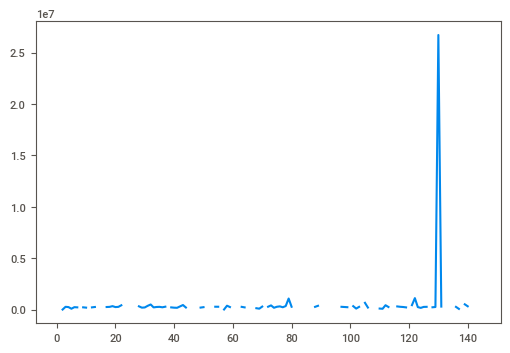

```python
df['salary'].plot()
```

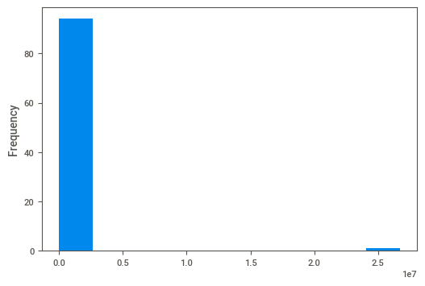

```python
df['salary'].plot.hist()
```

```python
df['salary'].min()
```

```
477.0
```

```python
def remove_outlier(df_in, col_name):
    q1 = df_in[col_name].quantile(0.25)
    q3 = df_in[col_name].quantile(0.75)
    iqr = q3-q1 #Interquartile range
    fence_low  = q1-1.5*iqr
    fence_high = q3+1.5*iqr
    df_out = df_in.loc[(df_in[col_name] > fence_low) & (df_in[col_name] < fence_high)]
    return df_out
```

```python
df[['poi','salary','bonus']]
```

|  | poi | salary | bonus |
| --- | --- | --- | --- |
| 0 | False | 201955.0 | 4175000.0 |
| 1 | False | NaN | NaN |
| 2 | False | 477.0 | NaN |
| 3 | False | 267102.0 | 1200000.0 |
| 4 | False | 239671.0 | 400000.0 |
| ... | ... | ... | ... |
| 141 | False | NaN | NaN |
| 142 | False | NaN | NaN |
| 143 | False | NaN | NaN |
| 144 | True | 158403.0 | NaN |
| 145 | False | NaN | NaN |

146 rows × 3 columns

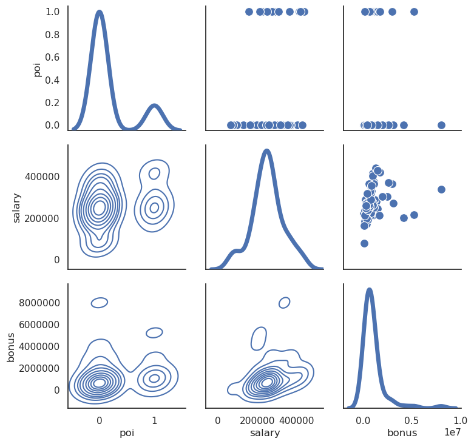

```python
import seaborn as sns
sns.set_theme(style="white")

base_salario_poi = remove_outlier(df[['poi','salary','bonus']],"salary")

g = sns.PairGrid(base_salario_poi, diag_sharey=False)
g.map_upper(sns.scatterplot, s=100)
g.map_lower(sns.kdeplot)
g.map_diag(sns.kdeplot, lw=5)
```

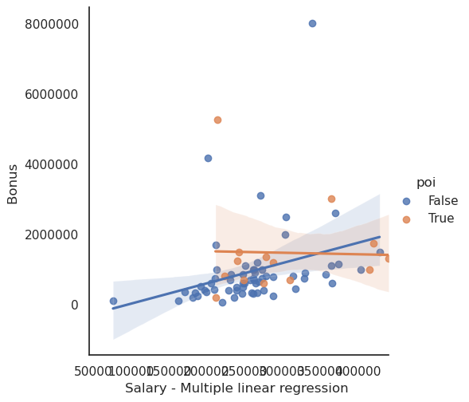

```python
# Plot sepal width as a function of sepal_length across days
g = sns.lmplot(
    data=base_salario_poi,
    x="salary", y="bonus", hue="poi",
    height=5
)

# Use more informative axis labels than are provided by default
g.set_axis_labels("Salary - Multiple linear regression ", "Bonus ")
```

```python
df.dtypes
```

```
bonus                        float64
deferral_payments            float64
deferred_income              float64
director_fees                float64
email_address                 object
exercised_stock_options      float64
expenses                     float64
from_messages                float64
from_poi_to_this_person      float64
from_this_person_to_poi      float64
loan_advances                float64
long_term_incentive          float64
other                        float64
poi                             bool
restricted_stock             float64
restricted_stock_deferred    float64
salary                       float64
shared_receipt_with_poi      float64
to_messages                  float64
total_payments               float64
total_stock_value            float64
name                          object
dtype: object
```

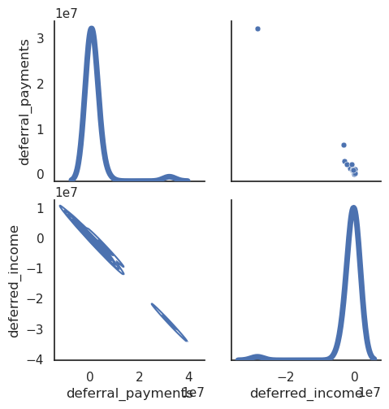

```python
import seaborn as sns
sns.set_theme(style="white")

base = df[['deferral_payments','deferred_income']]

g = sns.PairGrid(base, diag_sharey=False)
g.map_upper(sns.scatterplot, s=25)
g.map_lower(sns.kdeplot)
g.map_diag(sns.kdeplot, lw=5)
```

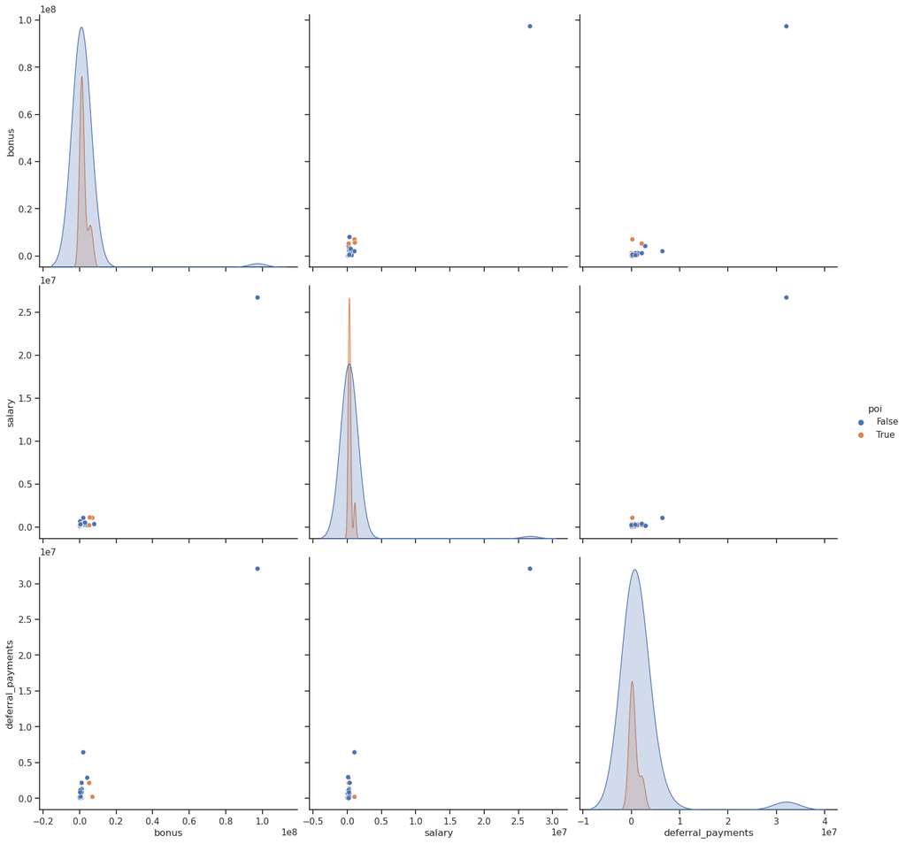

```python
sns.set_theme(style="ticks")

sns.pairplot(df[['poi','bonus','salary','deferral_payments']], hue="poi", height=5)
```

# Analise variavel Salario

## Base limpa em salario

```python
base_limpa_salary  = remove_outlier(df,'salary')
```

# Plot de Line Plot

Analise, foi limpa a base visando entender o comportamento e entender o padrão do grafico, dessa forma ficou mais simples e nitido ver o comportamento monetario dos individuos analisados

Por line plot foi visto o comportamento do dinheiro e suas anomalias

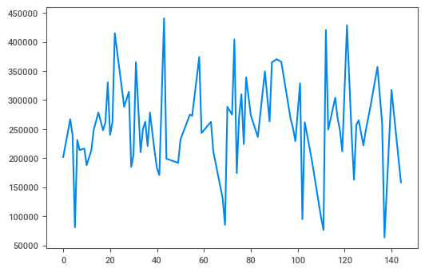

```python
base_limpa_salary['salary'].plot()
```

## Histograma

Com histograma é perceptivel o comportamento da frequencia com que os valores aparecem em suas respectivas capacidades de movimentação

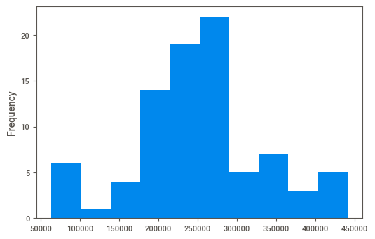

```python
base_limpa_salary['salary'].plot.hist()
```

## Box Plot Salary com Poi

Com box ploy pensei em como validar o comportamento monetario e classificar os dados entre fraudadores e não fraudadores, visando entender os dados monetarios de ambas as classes dos dados, pude coopreender que para os não fraudadores a taxa de variação do boxplot foi menor que o de fraudadores

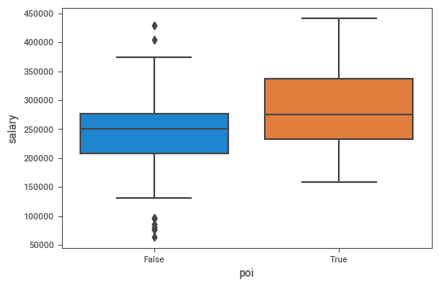

```python
#remove_outlier(df,'salary').boxplot(column='salary', by='poi')

sns.boxplot(x='poi',y='salary',data=base_limpa_salary)
```

## Analise da variavel Bonus

```python
base_limpa_bonus = remove_outlier(df,'bonus')
```

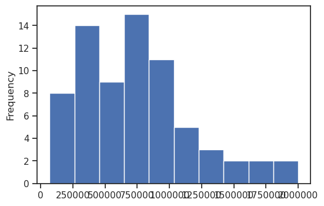

```python
base_limpa_bonus['bonus'].plot.hist()
```

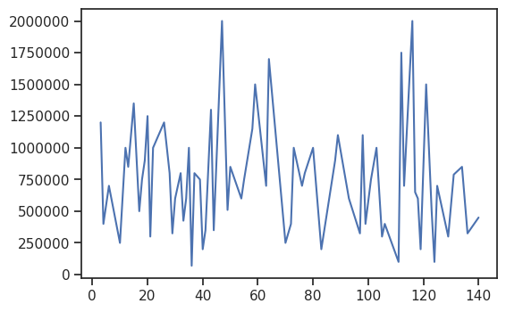

```python
base_limpa_bonus['bonus'].plot()
```

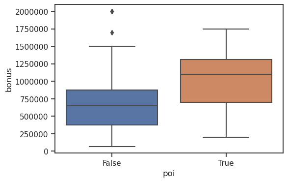

```python
sns.boxplot(x='poi',y='bonus',data=base_limpa_bonus)
```

# Análise multivariada de dados

Nesta seção, você deverá conduzir uma análise de dados multivariada. O objetivo desta etapa é encontrar relações e/ou correlações entre as variáveis da base de dados da Enron. Apesar de mais flexível que a etapa anterior, esta é uma das etapas mais importantes da ATP, uma vez que esta base de dados possui inúmeros relacionamentos interessantes a serem descobertos e reportados. Nesta etapa, você deverá criar visualizações, contudo, sempre no seguinte formato:

- Apresentar uma pergunta/hipótese sobre os dados,
- Criar uma visualização que responda esta pergunta ou confirme a hipótese, e
- Análise dos dados a partir desta visualização, respondendo textualmente a pergunta/hipótese afirmada anteriormente, assim como apresentando ao leitor os principais insights obtidos a partir da visualização.

Esta etapa do projeto requer que ao menos 20 visualizações bivariadas sejam criadas. Sinta-se a vontade para utilizar gráficos de barra, box-plots, violin plots, ou demais gráficos discutidos durante o curso. Note, contudo, que a utilização dos gráficos deverá ser apropriada, isto é, o tipo de cada gráfico deve ser aderente com os tipos de dados sendo apresentados.

```
Hipotese - Se tenho uma label na base de dados que marca um fraudador para um não fraudador, é possivel trassar um padrão nos perfis fraudadores e não fraudadores ? daria para agrupar esses perfils e gerar um padrão entre eles ? quais algoritmos de ML poderia utilizar e quais processos levaria para isso ?
```

### Analisar as colunas e identificar bonus/salario - vamos usar esses 2 colunas para identificar valores de ganho e usar variavel target para poi como nosso ponto principal de analise

```python
df.columns
```

```
Index(['bonus', 'deferral_payments', 'deferred_income', 'director_fees',
       'email_address', 'exercised_stock_options', 'expenses', 'from_messages',
       'from_poi_to_this_person', 'from_this_person_to_poi', 'loan_advances',
       'long_term_incentive', 'other', 'poi', 'restricted_stock',
       'restricted_stock_deferred', 'salary', 'shared_receipt_with_poi',
       'to_messages', 'total_payments', 'total_stock_value', 'name'],
      dtype='object')
```

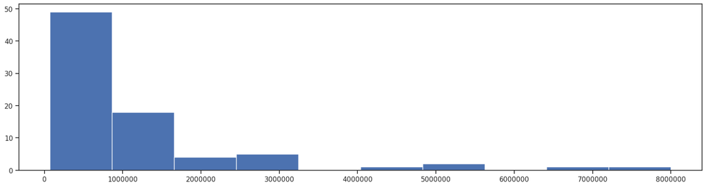

```python
plt.figure(figsize=(20,5))
plt.hist(df[df['bonus']<=0.2 * 1e8 ]['bonus'])
```

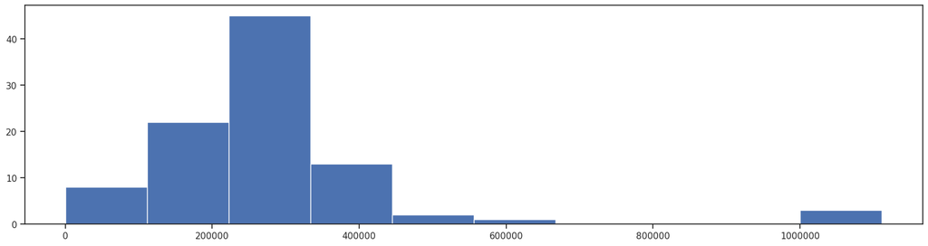

```python
plt.figure(figsize=(20,5))
plt.hist(df[df['salary']<=0.2 * 1e8 ]['salary'])
```

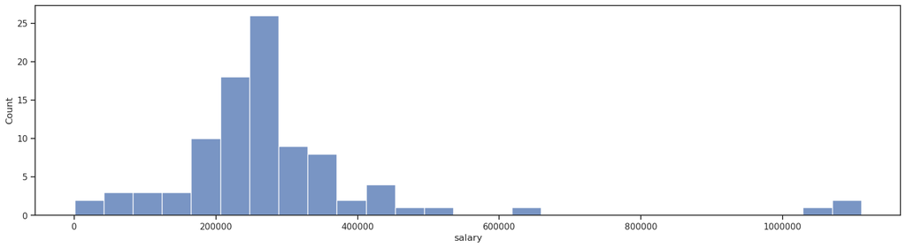

```python
plt.figure(figsize=(20,5))

sns.histplot(df[df['salary']<=0.2 * 1e8 ]['salary'])
```

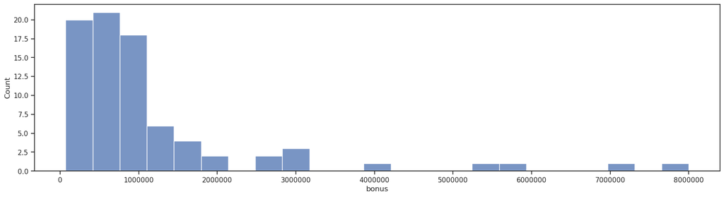

```python
plt.figure(figsize=(20,5))

sns.histplot(df[df['bonus']<=0.2 * 1e8 ]['bonus'])
```

[output not shown]

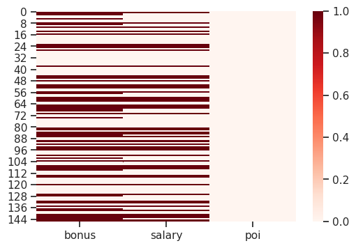

```python
sns.heatmap(data_limpa.isnull(),cmap="Reds")
```

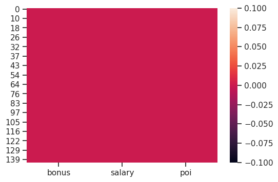

```python
sns.heatmap(data_limpa.dropna().isnull())
```

```python
baselimpa = data_limpa.dropna()
```

```python
!pip install tpot
```

```
     |████████████████████████████████| 87 kB 8.2 MB/s  eta 0:00:01
     |████████████████████████████████| 160 kB 29.3 MB/s eta 0:00:01
```

```python
from tpot import TPOTClassifier
from sklearn.datasets import load_iris
from sklearn.model_selection import train_test_split
import numpy as np
import pandas as pd
from sklearn.ensemble import RandomForestClassifier
from sklearn.model_selection import train_test_split
from sklearn.metrics import accuracy_score
```

```python
X = baselimpa.drop('poi', axis = 1)
```

```python
y = baselimpa['poi'].copy()
```

```python
X_train, X_test, Y_train, Y_test = train_test_split(X,y,test_size=0.3,random_state=42)
```

```python
tpot = TPOTClassifier(verbosity=2, max_time_mins=50)
tpot.fit(X_train, Y_train)
print(tpot.score(X_test, Y_test))
```

```
Generation 1 - Current best internal CV score: 0.8424242424242424

Generation 2 - Current best internal CV score: 0.8424242424242424

Generation 3 - Current best internal CV score: 0.8590909090909091

Generation 4 - Current best internal CV score: 0.8590909090909091

Generation 5 - Current best internal CV score: 0.8590909090909091

Generation 6 - Current best internal CV score: 0.8590909090909091

Generation 7 - Current best internal CV score: 0.8590909090909091

Generation 8 - Current best internal CV score: 0.8590909090909091

Generation 9 - Current best internal CV score: 0.8590909090909091

Generation 10 - Current best internal CV score: 0.8590909090909091

Generation 11 - Current best internal CV score: 0.8590909090909091

Generation 12 - Current best internal CV score: 0.8590909090909091

Generation 13 - Current best internal CV score: 0.8590909090909091

Generation 14 - Current best internal CV score: 0.8590909090909091

Generation 15 - Current best internal CV score: 0.8590909090909091

Generation 16 - Current best internal CV score: 0.8590909090909091

Generation 17 - Current best internal CV score: 0.8590909090909091

Generation 18 - Current best internal CV score: 0.8590909090909091

Generation 19 - Current best internal CV score: 0.8590909090909091

Generation 20 - Current best internal CV score: 0.8590909090909091

```

[output cut: 44 more lines]

```
Generation 43 - Current best internal CV score: 0.8590909090909091

Generation 44 - Current best internal CV score: 0.8590909090909091

Generation 45 - Current best internal CV score: 0.8757575757575757

50.05 minutes have elapsed. TPOT will close down.
TPOT closed during evaluation in one generation.
WARNING: TPOT may not provide a good pipeline if TPOT is stopped/interrupted in a early generation.


TPOT closed prematurely. Will use the current best pipeline.

Best pipeline: SGDClassifier(CombineDFs(MaxAbsScaler(input_matrix), input_matrix), alpha=0.01, eta0=1.0, fit_intercept=False, l1_ratio=1.0, learning_rate=invscaling, loss=modified_huber, penalty=elasticnet, power_t=0.5)
0.76
```

```python
tpot.export('tpot_eron_pipeline.py')
```

```python
!cat tpot_eron_pipeline.py
```

```
import numpy as np
import pandas as pd
from sklearn.linear_model import SGDClassifier
from sklearn.model_selection import train_test_split
from sklearn.pipeline import make_pipeline, make_union
from sklearn.preprocessing import MaxAbsScaler
from tpot.builtins import StackingEstimator
from sklearn.preprocessing import FunctionTransformer
from copy import copy

# NOTE: Make sure that the outcome column is labeled 'target' in the data file
tpot_data = pd.read_csv('PATH/TO/DATA/FILE', sep='COLUMN_SEPARATOR', dtype=np.float64)
features = tpot_data.drop('target', axis=1)
training_features, testing_features, training_target, testing_target = \
            train_test_split(features, tpot_data['target'], random_state=None)

# Average CV score on the training set was: 0.8757575757575757
exported_pipeline = make_pipeline(
    make_union(
        MaxAbsScaler(),
        FunctionTransformer(copy)
    ),
    SGDClassifier(alpha=0.01, eta0=1.0, fit_intercept=False, l1_ratio=1.0, learning_rate="invscaling", loss="modified_huber", penalty="elasticnet", power_t=0.5)
)

exported_pipeline.fit(training_features, training_target)
results = exported_pipeline.predict(testing_features)
```

# Visualizações efetivas

Nesta seção, você deve **escolher** e **melhorar** 5 visualizações criadas anteriormente. A chave aqui é melhorar estas visualizações com o objetivo de apresentá-las a uma audiência que não conheça a base de dados da Enron e/ou não trabalhe com análise de dados. **Sendo assim, garanta que o tamanho, cores, texturas e outras componentes visuais sejam bem escolhidas e utilizadas, sempre visando garantir que a informação seja passada de forma clara e correta para a audiência.**

Para cada um destas visualizações, garanta que as seguintes etapas foram seguidas:

1. Criação de visualização: Criar novamente a visualização, garantindo que ela possui título e rótulos nos eixos e legenda (caso necessário)
2. Cores: Garantir que o uso de cores é correto, de acordo com o objetivo da visualização e também com escalas de cores visando leitores daltônicos
3. Cores e tamanhos: Garantir que texturas e tamanhos são utilizados de forma correta
4. Chart junk: Garantir que a visualização possui um baixo fator de "chart junk"
5. Avaliação por pares: você deverá angariar feedback de três pessoas sobre sua visualização. Você deverá apresentar o feedback de cada pessoa, assim como deve discutir, de forma textual, se este feedback acarretou em alguma mudança de design. Você deve apresentar evidências das mudanças realizadas, isto é, a visualização **antes** e **depois** do *feedback*.
6. Descrição: cada visualização deve ser acompanhada de uma descrição que inclua as principais descobertas (*insights*) que podem ser extraídos a partir dela.

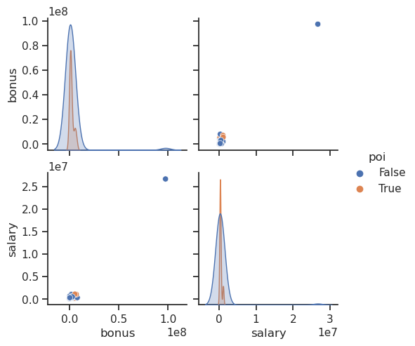

```python
plt.figure(figsize=(10,5))

sns_plot = sns.pairplot(data_limpa[['bonus', 'salary', 'poi']], hue="poi")
```

```python
df
```

|  | bonus | deferral_payments | deferred_income | director_fees | email_address | exercised_stock_options | expenses | from_messages | from_poi_to_this_person | from_this_person_to_poi | ... | other | poi | restricted_stock | restricted_stock_deferred | salary | shared_receipt_with_poi | to_messages | total_payments | total_stock_value | name |
| --- | --- | --- | --- | --- | --- | --- | --- | --- | --- | --- | --- | --- | --- | --- | --- | --- | --- | --- | --- | --- | --- |
| 0 | 4175000.0 | 2869717.0 | -3081055.0 | NaN | phillip.allen@enron.com | 1729541.0 | 13868.0 | 2195.0 | 47.0 | 65.0 | ... | 152.0 | False | 126027.0 | -126027.0 | 201955.0 | 1407.0 | 2902.0 | 4484442.0 | 1729541.0 | ALLEN PHILLIP K |
| 1 | NaN | 178980.0 | NaN | NaN | NaN | 257817.0 | 3486.0 | NaN | NaN | NaN | ... | NaN | False | NaN | NaN | NaN | NaN | NaN | 182466.0 | 257817.0 | BADUM JAMES P |
| 2 | NaN | NaN | -5104.0 | NaN | james.bannantine@enron.com | 4046157.0 | 56301.0 | 29.0 | 39.0 | 0.0 | ... | 864523.0 | False | 1757552.0 | -560222.0 | 477.0 | 465.0 | 566.0 | 916197.0 | 5243487.0 | BANNANTINE JAMES M |
| 3 | 1200000.0 | 1295738.0 | -1386055.0 | NaN | NaN | 6680544.0 | 11200.0 | NaN | NaN | NaN | ... | 2660303.0 | False | 3942714.0 | NaN | 267102.0 | NaN | NaN | 5634343.0 | 10623258.0 | BAXTER JOHN C |
| 4 | 400000.0 | 260455.0 | -201641.0 | NaN | frank.bay@enron.com | NaN | 129142.0 | NaN | NaN | NaN | ... | 69.0 | False | 145796.0 | -82782.0 | 239671.0 | NaN | NaN | 827696.0 | 63014.0 | BAY FRANKLIN R |
| ... | ... | ... | ... | ... | ... | ... | ... | ... | ... | ... | ... | ... | ... | ... | ... | ... | ... | ... | ... | ... | ... |
| 141 | NaN | NaN | -25000.0 | 108579.0 | NaN | NaN | 1413.0 | NaN | NaN | NaN | ... | NaN | False | NaN | NaN | NaN | NaN | NaN | 84992.0 | NaN | WINOKUR JR. HERBERT S |
| 142 | NaN | NaN | NaN | NaN | john.wodraska@enron.com | NaN | NaN | NaN | NaN | NaN | ... | 189583.0 | False | NaN | NaN | NaN | NaN | NaN | 189583.0 | NaN | WODRASKA JOHN |
| 143 | NaN | NaN | NaN | NaN | NaN | 139130.0 | NaN | NaN | NaN | NaN | ... | NaN | False | NaN | NaN | NaN | NaN | NaN | NaN | 139130.0 | WROBEL BRUCE |
| 144 | NaN | NaN | NaN | NaN | scott.yeager@enron.com | 8308552.0 | 53947.0 | NaN | NaN | NaN | ... | 147950.0 | True | 3576206.0 | NaN | 158403.0 | NaN | NaN | 360300.0 | 11884758.0 | YEAGER F SCOTT |
| 145 | NaN | NaN | NaN | NaN | NaN | 192758.0 | 55097.0 | NaN | NaN | NaN | ... | NaN | False | NaN | NaN | NaN | NaN | NaN | 55097.0 | 192758.0 | YEAP SOON |

146 rows × 22 columns

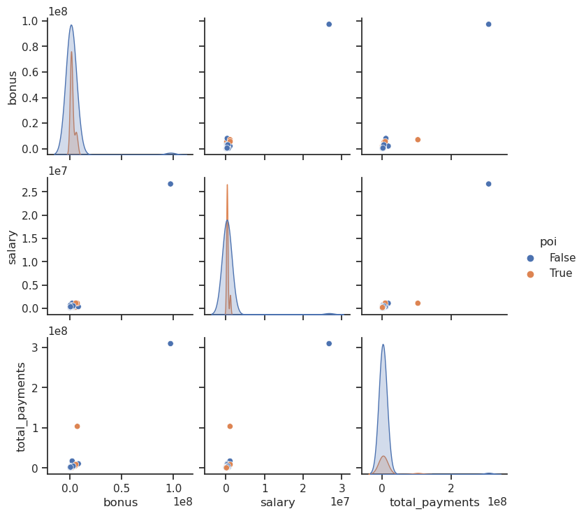

```python
sns.pairplot(df[['bonus', 'salary', 'poi',"total_payments"]], hue="poi")
```

```python
#sns.pairplot(df[['bonus', 'salary', 'poi',"total_payments"]], hue="poi")
#g = sns.FacetGrid(df, col="bonus",  row="poi")
cores = dict(poi='red',salary='orange',bonus="purple",total_payments="green")
sns.pairplot(df, hue="poi", height=3)
```

[figure not shown]

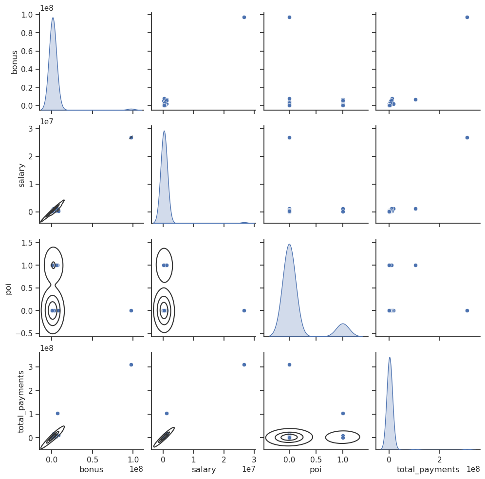

```python
base = df[['bonus', 'salary', 'poi',"total_payments"]]
g = sns.pairplot(base, diag_kind="kde")
g.map_lower(sns.kdeplot, levels=4, color=".2")
```

# Conclusão

## Reflexão

Nesta seção você deve apresentar uma reflexão sobre sua atuação neste projeto e sobre os conceitos aprendidos e praticados. A idéia é apresentar (1) o que você fez bem e (2) o que você poderia ter feito diferente. Esta reflexão deve possuir ao menos 2500 caracteres (sem espaços).

```
Escreva sua resposta aqui.
Minha idéia era analisar os fraudadores e usar técnicas de clean data para limpar a base e entender melhor o comportamento dos fraudadores, pensei tambem em montar uma api para esse tipo de serviço, quis entender o perfil dos "poi" e ver como "seguir o dinheiro" poderia levar a analisar esse tipo de comportamento de fraud.

Achei trabalhar nessa base, um pouco complexo, nunca tinha trabalhado nela, pesquisei algumas coisas sobre mas não foi uma base que me fez querer estudar mais e nem me senti motivado para tal, contudo lembro que em algum momento ja tinha usado um auto EDA e fiz uma analise simples nele para entender melhor essa base, me ajudou a ver com mais claresa os dados e pude perceber a quantidade de outliears que tem, percebi tambem o perfil dos fraudadores analisando os dados e entendi como se comportavam, confesso que não fui muito afundo nisso, outra coisa que gostei muito foi o fato de de ter praticado mais meu pandas, no trabalho uso muito spark/sql, pensei muito em montar um lake e matar tudo la, enfim, seaborn é realmente muito poderoso, mas confeço que isso deve ser muito bom na mão de um cientista, adorei descobrir todas as opções de graficos.

Sobre o que mudaria ou faria diferente, acredito que mudaria a forma, penso em algum automl para otimizar o processo de EDA, tambem adoraria usar alguma técnica legal de PCA para entender quais variaveis mais importantes, e para modelagem de dados pensando em gerar api acho que montaria em flask/fastAPI.
```

# Referências

Adicione na célula abaixo todas as referências utilizadas durante a preparação deste relatório.

```
Adicione as referências aqui.
https://github.com/missmariss31/enron
https://seaborn.pydata.org/generated/seaborn.pairplot.html
https://www.youtube.com/watch?v=5jORoEE-CEk
https://towardsdatascience.com/deriving-patterns-of-fraud-from-the-enron-dataset-64cbceb65c36
https://www.kaggle.com/ankur561999/data-cleaning-enron-email-dataset
https://towardsdatascience.com/exploratory-data-analysis-eda-python-87178e35b14
https://towardsdatascience.com/sweetviz-automated-eda-in-python-a97e4cabacde
```

## Trabalhos futuros

Na célula abaixo, apresente ao menos 3 (três) idéias diferentes que você gostaria de atuar em um trabalho futuro com esta mesma base de dados. Elas podem incluir, por exemplo, o uso de aprendizagem de máquina para um objetivo específico, ou criar/analisar variáveis que não tivemos tempo de fazer durante a execução deste trabalho. Você deve fornecer **detalhes** sobre como cada idéia seria abordada, especificando as técnicas e/ou metodologia a ser seguida. Esta seção deve possuir ao menos 2500 caracteres (sem espaços).

## Ideia - 1

```
Escreva sua resposta aqui.
1) Montar uma estrutura de Automação para Analise Automatica desses dados usando AIRFLOW, SIM, gosto dessa linha de automação, penso que poderia existir um processo automatizado para fazer feature engineer, e upar isso pra uma feature store, penso tambem em montar uma api com esses dados para servir como poc de MLOps, por ser uma base toda "torta"  penso que poderia montar uma api, gosto de pensar em usar analises baseadas em clustering para gerar agrupamentos dos fraudadores por distancias euclidianas, talvez um KNN ou Kmean, claro remomvendo a feature POI para para analisar os dados brutos e ver se é possivel analisar dessa forma.
```

### Imagem Ilustrativa - Airflow

[figure not shown]

## Ideia - 2

```
2) Gostaria de testar uma analise focada em PCA, olhando para quais de fato sãos as princiapais caracteristicas dos grupos de fraude, penso em reduzir as dimensões e buscar melhores features para treino, aqui acho que valeria té usar machine learning com sklearn mesmo ou até mesmo um keras da vida.
```

### Imagem Ilustrativa - PCA

[figure not shown]

## Ideia - 3

```
3) Penso em tambem usar deep learning para durante a etapa de trainning ele ja fazer o processo de feature engineer interno dentro da propria rede, talvez uma lstm por ser uma base temporal e que envolve dinheiro, uma regressão seria mt bom tambem para poder ver como foi o processo de fraude com o tempo, aqui acredito que valeria ter um pipeline no gitlab ou codefresh para ter um acompanhamento mais visual e mais performatico da aplicação
```

### Imagem Ilustrativa - Codefresh - Pipeline

[figure not shown]

# Último passsos

1. Salve este relatório como um jupyter notebook em formato `.ipynb`
2. Salve uma cópia deste relatório como um arquivo PDF, isto é, com extensão `.pdf`
3. Compacte ambos em um único arquivo com extensão ZIP no seguinte formato:(`analise-enron-primeiro_nome-ultimo_nome.zip`)
4. Envie o seu relatório para avaliação no ambiente virtual de aprendizagem

## Fontes

https://github.com/missmariss31/enron